# Data Study #2 week cmplt

```python
import pandas as pd
import numpy as np

alldfs = [var for var in dir() if isinstance(eval(var), pd.core.frame.DataFrame)]
print(alldfs)
```

```
[]
```

```python
import os
print (os.getcwd()) #현재 디렉토리의
os.chdir('./Desktop/bigdata/')
```

```
C:\Users\kyuri Im
```

```python
#1.데이터 불러오기 (BUYTEST.csv)
df1 = pd.read_csv('./Data_Study_19.05.19~/20190526 과제/20190526 과제/BUYTEST.csv')
```

```python
#2.데이터 검토 및 변수 별 기초통계 확인(명목형, 수치형)
df1.info()
cate_cols = [col for col in df1.columns if df1[col].dtype == 'object']
num_cols =[col for col in df1.columns if df1[col].dtype in ['float', 'int64']]
print(cate_cols)
print(num_cols)
print(len(cate_cols)+len(num_cols))

df1[num_cols].describe()
```

```
<class 'pandas.core.frame.DataFrame'>
RangeIndex: 10000 entries, 0 to 9999
Data columns (total 26 columns):
ID          10000 non-null object
RESPOND     10000 non-null int64
AGE         10000 non-null object
INCOME      10000 non-null object
SEX         9766 non-null object
MARRIED     10000 non-null object
FICO        10000 non-null object
OWNHOME     10000 non-null object
LOC         10000 non-null object
CLIMATE     10000 non-null int64
BUY6        10000 non-null int64
BUY12       10000 non-null int64
BUY18       10000 non-null int64
BUY24       10000 non-null int64
ORGSRC      9479 non-null object
DISCBUY     10000 non-null int64
RETURN24    10000 non-null int64
COA6        10000 non-null int64
C1          10000 non-null int64
C2          10000 non-null int64
C3          10000 non-null int64
C4          10000 non-null int64
C5          10000 non-null int64
C6          10000 non-null int64
C7          10000 non-null int64
PURCHTOT    10000 non-null int64
dtypes: int64(17), object(9)
memory usage: 2.0+ MB
['ID', 'AGE', 'INCOME', 'SEX', 'MARRIED', 'FICO', 'OWNHOME', 'LOC', 'ORGSRC']
['RESPOND', 'CLIMATE', 'BUY6', 'BUY12', 'BUY18', 'BUY24', 'DISCBUY', 'RETURN24', 'COA6', 'C1', 'C2', 'C3', 'C4', 'C5', 'C6', 'C7', 'PURCHTOT']
26
```

|  | RESPOND | CLIMATE | BUY6 | BUY12 | BUY18 | BUY24 | DISCBUY | RETURN24 | COA6 | C1 | C2 | C3 | C4 | C5 | C6 | C7 | PURCHTOT |
| --- | --- | --- | --- | --- | --- | --- | --- | --- | --- | --- | --- | --- | --- | --- | --- | --- | --- |
| count | 10000.000000 | 10000.000000 | 10000.000000 | 10000.000000 | 10000.000000 | 10000.000000 | 10000.000000 | 10000.000000 | 10000.000000 | 10000.000000 | 10000.00000 | 10000.000000 | 10000.00000 | 10000.00000 | 10000.000000 | 10000.000000 | 10000.000000 |
| mean | 0.076700 | 20.343000 | 0.128300 | 0.209900 | 0.347100 | 254.045100 | 0.270000 | 0.070900 | 0.028900 | 0.155300 | 1.01220 | 0.563500 | 0.53730 | 0.35400 | 3.491600 | 0.174500 | 6.288400 |
| std | 0.266128 | 6.108689 | 0.346195 | 0.436648 | 0.570661 | 153.422061 | 0.443982 | 0.256671 | 0.167534 | 1.488087 | 6.28347 | 4.240303 | 4.54936 | 2.92789 | 15.493222 | 1.863437 | 27.276327 |
| min | 0.000000 | 10.000000 | 0.000000 | 0.000000 | 0.000000 | 60.000000 | 0.000000 | 0.000000 | 0.000000 | 0.000000 | 0.00000 | 0.000000 | 0.00000 | 0.00000 | 0.000000 | 0.000000 | 0.000000 |
| 25% | 0.000000 | 20.000000 | 0.000000 | 0.000000 | 0.000000 | 149.000000 | 0.000000 | 0.000000 | 0.000000 | 0.000000 | 0.00000 | 0.000000 | 0.00000 | 0.00000 | 0.000000 | 0.000000 | 0.000000 |
| 50% | 0.000000 | 20.000000 | 0.000000 | 0.000000 | 0.000000 | 214.000000 | 0.000000 | 0.000000 | 0.000000 | 0.000000 | 0.00000 | 0.000000 | 0.00000 | 0.00000 | 0.000000 | 0.000000 | 0.000000 |
| 75% | 0.000000 | 20.000000 | 0.000000 | 0.000000 | 1.000000 | 312.000000 | 1.000000 | 0.000000 | 0.000000 | 0.000000 | 0.00000 | 0.000000 | 0.00000 | 0.00000 | 0.000000 | 0.000000 | 0.000000 |
| max | 1.000000 | 30.000000 | 2.000000 | 3.000000 | 3.000000 | 1253.000000 | 1.000000 | 1.000000 | 1.000000 | 46.000000 | 115.00000 | 127.000000 | 125.00000 | 90.00000 | 249.000000 | 62.000000 | 446.000000 |

```python
df1[cate_cols].describe()
```

|  | ID | AGE | INCOME | SEX | MARRIED | FICO | OWNHOME | LOC | ORGSRC |
| --- | --- | --- | --- | --- | --- | --- | --- | --- | --- |
| count | 10000 | 10000 | 10000 | 9766 | 10000 | 10000 | 10000 | 10000 | 9479 |
| unique | 10000 | 59 | 85 | 2 | 3 | 196 | 3 | 8 | 7 |
| top | 109419955 | 44 | 60 | M | 1 | 700 | 0 | E | O |
| freq | 1 | 503 | 297 | 5277 | 5705 | 165 | 6503 | 2261 | 2017 |

```python
#SEX, ORGSRC 결측값 있음
#ORGSRC, INCOME, AGE 연속형으로 재분류
num_cols += ['AGE', 'INCOME','ORGSRC']
cate_cols = [col for col in df1.columns if col not in num_cols]
```

```python
df1['INCOME'].unique()
```

```
array(['67', '72', '70', '56', '66', '48', '49', '64', '65', '$null$',
       '58', '40', '57', '33', '17', '71', '25', '51', '52', '38', '54',
       '29', '63', '61', '19', '35', '31', '20', '24', '45', '73', '30',
       '53', '41', '37', '43', '60', '44', '27', '34', '21', '69', '55',
       '59', '18', '68', '39', '74', '50', '82', '28', '42', '114', '76',
       '46', '36', '62', '84', '16', '47', '81', '32', '75', '79', '77',
       '78', '26', '83', '22', '15', '86', '23', '92', '87', '105', '88',
       '107', '90', '93', '99', '85', '101', '80', '89', '96'],
      dtype=object)
```

```python
#3.데이터 시각화 : 범주형 변수와 수치형 변수 간의 관계를 보기 위해 박스 플롯 작성 CHAS(찰스강 인접여부: F, T)와 MEDV(집값의 중앙값, 단위 $1000)
import matplotlib.pyplot as plt
import seaborn as sns
```

[output not shown]

```python
#4.결측치 처리 : 수치형->평균값, 범주형->최빈값
#SEX, ORGSRC 결측값 있음
df1['SEX'].fillna(df1['SEX'].mode()[0], inplace=True)
df1['ORGSRC'].fillna(df1['ORGSRC'].mode()[0], inplace=True)

df1.isnull().sum()

df1['AGE'].unique()
df1['AGE'] = df1['AGE'].replace('$null$', round(pd.to_numeric(df1['AGE'],errors='coarce').mean()))
df1['AGE'].unique()

###
#INCOME, FICO, MARRIED  ,  OWNHOME        '$null$'  있음
for col in df1.columns:
    print(col,'\n',df1[col].unique(),'\n','-'*50)



for col in ['INCOME', 'FICO']:
    df1[col].replace('$null$', round(pd.to_numeric(df1[col], errors='coarce').mean()), inplace=True)


for col in ['OWNHOME', 'MARRIED']:
    df1[col].replace('$null$', df1[col].mode()[0],inplace=True)

for col in df1.columns:
    print(col,'\n',df1[col].unique(),'\n','-'*50)


#age income
for col in cate_cols:
    if col in ['AGE','INCOME','FICO']:
        df1[col] = df1[col].astype(np.int8)
```

```
ID
 ['1371057' '2093270' '2783726' ... '996739474' '998468785' '998947462']
 --------------------------------------------------
RESPOND
 [0 1]
 --------------------------------------------------
AGE
 ['71' '53' '45' '32' '35' '43' '39' '66' 45 '52' '29' '48' '67' '44' '59'
 '47' '49' '36' '23' '58' '50' '63' '55' '54' '42' '46' '60' '56' '37'
 '41' '34' '38' '33' '27' '68' '31' '19' '64' '40' '51' '28' '57' '18'
 '26' '21' '61' '20' '62' '30' '65' '69' '25' '72' '73' '70' '22' '24'
 '75' '74']
 --------------------------------------------------
INCOME
 ['67' '72' '70' '56' '66' '48' '49' '64' '65' '$null$' '58' '40' '57' '33'
 '17' '71' '25' '51' '52' '38' '54' '29' '63' '61' '19' '35' '31' '20'
 '24' '45' '73' '30' '53' '41' '37' '43' '60' '44' '27' '34' '21' '69'
 '55' '59' '18' '68' '39' '74' '50' '82' '28' '42' '114' '76' '46' '36'
 '62' '84' '16' '47' '81' '32' '75' '79' '77' '78' '26' '83' '22' '15'
 '86' '23' '92' '87' '105' '88' '107' '90' '93' '99' '85' '101' '80' '89'
 '96']
 --------------------------------------------------
SEX
 ['M' 'F']
 --------------------------------------------------
MARRIED
 ['1' '0' '$null$']
 --------------------------------------------------
FICO
 ['719' '751' '725' '684' '651' '691' '694' '659' '692' '707' '705' '693'
 '698' '713' '703' '680' '610' '670' '686' '733' '714' '732' '706' '635'
 '687' '654' '720' '688' '646' '734' '717' '676' '673' '709' '727' '724'
 '657' '678' '738' '729' '744' '675' '701' '681' '643' '658' '650' '740'
 '672' '690' '$null$' '708' '685' '742' '677' '716' '704' '697' '695'
 '710' '715' '739' '668' '632' '737' '748' '718' '722' '666' '721' '769'
 '642' '683' '669' '712' '649' '679' '770' '674' '689' '749' '735' '730'
 '728' '616' '700' '777' '665' '699' '741' '664' '633' '648' '711' '682'
 '637' '661' '798' '647' '745' '702' '645' '757' '726' '696' '746' '667'
 '640' '619' '639' '662' '631' '750' '652' '660' '736' '671' '638' '625'
 '663' '723' '615' '630' '656' '731' '763' '603' '758' '644' '653' '655'
```

[output cut: 316 more lines]

```
 --------------------------------------------------
PURCHTOT
 [  0  86 210 128  30  18  32   3 196   9  88  11 109  85  52 117  71 122
  23  34  39  81 102  60  64  65  26 186  21  25  51  49  41 116  58  12
  53 214  87  89 152  50 140 138  84 346 125  78  22 142  99  36  66 134
  79 114  45 115 229 147  67  37  44  61  42  70  83 150   6  93  31  33
 178 126  76  14  35  46  80  68  91 153  54  95  17  94  19 105  16 124
  27 108 151  62  20  63  43 113 163  47 288  10 118 160 127   5 171  90
  40  56 104  69  24 167 184 137 256 131  57 121 168  29  92 136 107  82
   1 208 106 129  72  96 174  97  48 123 145  77 148 173 139  13  74  75
 130 100 119 206 155 103 201 141 143 157   7 180 217 199  59  55 158 101
 304 194 197 275 111   8  98  73 307 156 161 340  38 183 110 135 192 177
 165 166 175 242 149 446 182 213 225  15 295 181 112   4   2 203 202 218
 189 263 132 221 363 254 187 245]
 --------------------------------------------------
```

```python
df1['AGE'] = df1['AGE'].astype('int')
df1['INCOME'] = df1['INCOME'].astype('int')
df1['MARRIED'] = df1['MARRIED'].astype('int')
df1['OWNHOME'] = df1['OWNHOME'].astype('int')
df1['AGE'] = df1['AGE'].astype('int')

cate_cols = [col for col in df1.columns if df1[col].dtype == 'object']
num_cols =[col for col in df1.columns if df1[col].dtype in ['float', 'int64']]
cate_cols += ['CLIMATE','DISCBUY','RETURN24', 'COA6']
```

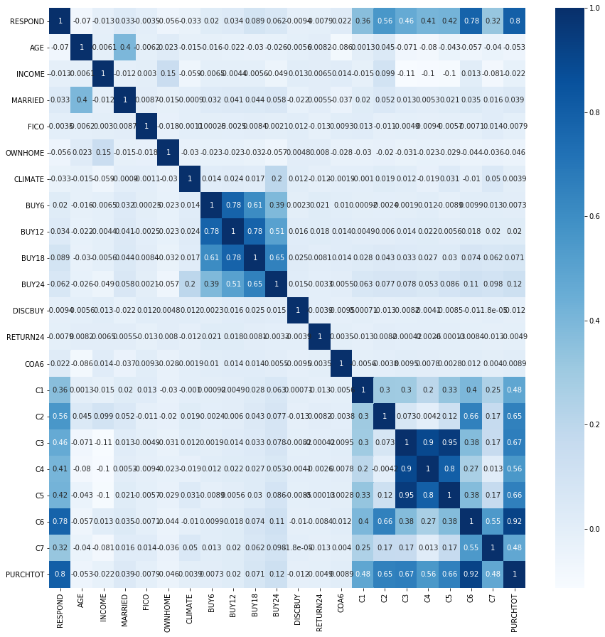

```python
#5.변수간 상관관계 확인
plt.figure(figsize= (15,15))
sns.heatmap(df1.corr(),annot=True, cmap='Blues')
```

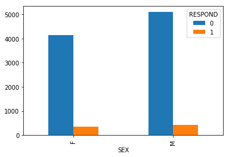

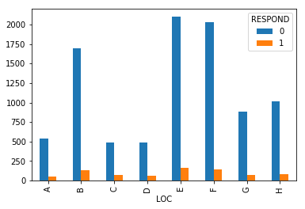

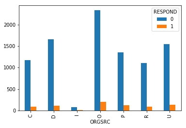

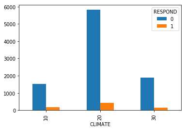

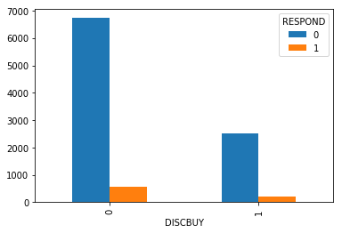

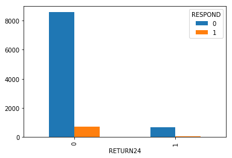

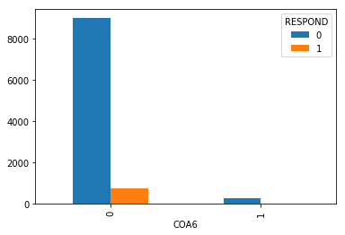

```python
for col in cate_cols:
    if col not in ['RESPOND', 'ID']:
        pd.crosstab(df1[col],df1['RESPOND']).plot.bar()
        plt.show
```

```python
#6.Training data 균형 맞추기->
#목표변수 (Respond) 값 0과 1의 비율이 92:7 (=13:1) 로, 결과가 편향될 수 있음 -> SMOTE를 통한 데이터 불균형처리
from sklearn.datasets import make_classification
from sklearn.decomposition import PCA
!pip install imblearn
from imblearn.over_sampling import SMOTE
```

```python
x=pd.get_dummies(df1.iloc[:,1:], drop_first=True)


pd.set_option('display.max_columns', 500)
```

```python
sm = SMOTE(ratio='auto', kind='regular')
x_resampled, y_resampled = sm.fit_sample(x, x['RESPOND'])
x_resampled = pd.DataFrame(x_resampled)
x_resampled.columns = x.columns

# smote로 샘플링한 후 데이터 프레임으로 변경했고, 컬럼명을 불러다 지정해줬다.
```

### SMOTE의 개념

불균형 자료의 경우 모델을 편향되게 할 수 있다. 예를 들어, 모든 인풋에 대해 결과값이 0인 모델을 만들게 되는데 그렇게 되도 정확도는 높게 나오기 때문이 그렇기 때문에 불균형 자료에 대한 사전 처리가 필요하다. 다운샘플링의 경우 자료의 손실이 많고, 오버샘플링의 경우 과적합의 문제가 있을 수 있다. 그래서 단순 오버샘플링 대신 SMOTE 알고리즘을 이용하여 불균형 자료를 처리하는 방법이 많이 사용되고 있다.

> smote가 사용하는 방법은 단순하다. 적은 수의 클래스의 데이터 포인트에서 근접이웃들을 찾고, 각 데이터 포인트와의 사이에 선을 긋는다. 그 선상에서 임의의 점을 생성한다.

[figure not shown]

위의 이미지를 보면 5개의 근접이웃을 찾고 연결하여 그 선 위의 임의의 점을 선택하여 샘플을 생성한다.

### 의사결정 나무(Decision Tree)

의사 결정 나무는 분기 때마다 변수의 영역을 나누는 모델이다. 그 기준은 **순도(Homegeneity)** 가 증가하고, **불순도(Impurity)** 또는 불확실성이 감소하는 방향으로 진행되는데 이걸 **정보획득(Information Gain)** 이라고 한다.

#### 분류 기준이 되는 지표

어떤 데이터가 이 조건에 충족하는지 보기 위한 지표는 대표적으로 3가지가 있다

- **엔트로피(Entropy)**
  $$ Entropy(A) = \sum_ {i=1}^d R_i\Bigl( - \sum_ {k=1}^m log_ {2}(P_k) \Bigl) $$ ($P_k$ = A영역에 속한 레코드 중 k범주에 속하는 레코드의 비율, $R_i$=분할 전 레코드 중 분할 후 i영역에 속하는 레코드의 비율)

```
* Information Gain: 지정된 속성이 얼마나 잘 training example들간을 구분하는가에 대한 수치.
* Entropy: example들의 집합에서의 혼합성(impurity)을 나타냄
```

- **지니계수(Gini Index)**
  $$ G.I(A) = \sum_ {i=1}^d \Bigl( R_i \Bigl(1- \sum_ {k=1}^m P_ {ik}^2 \Bigl) \Bigl) $$
- 다른 한가지인 오분류오차의 경우 미분이 불가능하기 때문에 잘 쓰이지 않는다.

[figure not shown]

#### 분류 과정

의사결정 나무의 모델링 방식은 처음에 한 변수를 선택하여 크기로 오더링 하고 첫번째 레코드와 나머지 레코드들로 분류해 엔트로피를 구하고, 첫번째와 두번째 레코드와 나머지로 분류해 레코드를 구하는 방식으로 가능한 모든 분기의 엔트로피를 구한 뒤 다른 변수들에 대해서도 같은 과정을 반복한다. 그 중에서 가장 엔트로피가 많이 감소하는 분기를 택해 분류한다. 이와 같은 방법을 시행하면 계산해야 하는 식의 수는 $d(n-1)$이 된다.

위의 방식으로 분기를 계속하면 분기가 진행됨에 따라 오분류율이 감소하다가 다시 증가하는 점이 오는데 이러한 과적합을 방지하기 위해 **가지치기(Pruning)** 를 진행한다. terminal node의 순도가 100%가 된 상태를 **Full Tree** 라고 하는데, 적정선에서 가지들끼리 merge해 주는 것을 말한다.

#### 가지치기

- **가지치기의 비용함수**
  $$ CC(T) = ERR(T) + \alpha \times L(T) $$

$CC(T)$=의사결정나무의 비용 복잡도(=오류가 적으면서 terminal node가 적은 단순한 모델일 수록 작은 값)  
$ERR(T)$=검증데이터에 대한 오분류율  
$L(T)$=terminal node의 수(구조의 복잡도)  
$\alpha=ERR(T)$와 $L(T)$를 결합하는 가중치(사용자에 의해 부여됨, 보통 0.01~0.1의 값을 씀)

#### 의사결정 나무의 분류

| 알고리즘 | 평가 기준(지수) | 분류방법 |
| --- | --- | --- |
| ID3 | Entropy | 다지분리 |
| C 4.5 | Information Gain | 다지분리(범주) 및 이진분리(수치) |
| C 5.0 | Information Gain | 다지분리 및 이진분리 |
| CHAID | 카이제곱(범주), F검정(수치) | 통계적 접근방식 |
| CART | Gini Index(범주), 분산의 차이(수치) | 통계적 접근방식, 항상 이진 |

> C4.5는 속성이 갖는 범주값의 수만큼 분리를 하기 때문에 실 데이터의 분석에서 가지가 매우 잘게 나눠지는 문제가 있다. 반면, CART는 딱 2개로만 분리하기 때문에 지나치게 단순화되는 문제가 발생할 수 있다

#### 의사결정 나무에 대하여

의사결정 나무는 계산복잡성 대비 성능이 좋고, 변수에 대한 설명이 용이하다는 장점이 있다. 하지만 **결정경계(Decision Boundary)** 가 데이터축에 수직이기 때문에 비선형인 데이터에 대해선 적합하지 않은 단점이 있고 이를 해결하기 위해 등장한 것이 **Random Forest** 이다.

```python
#8. Entropy Decision Tree(ID3) 생성
#9. Gini Index Decision Tree(CART) 생성

from sklearn.tree import DecisionTreeClassifier,export_graphviz # Import Decision Tree Classifier
from sklearn.model_selection import train_test_split # Import train_test_split function
from sklearn import metrics #Import scikit-learn metrics module for accuracy calculation

y = x_resampled['RESPOND']
x_train, x_test, y_train, y_test = train_test_split(x_resampled, y, test_size=0.2, random_state=1)
entropy = DecisionTreeClassifier(criterion='entropy', random_state=1)
gini = DecisionTreeClassifier(criterion='gini', random_state=1)
ent_fit = entropy.fit(x_train, y_train)
gini_fit = gini.fit(x_train, y_train)
'''
random_state : 데이터 분할시 셔플이 이루어지는데 이를 위한 시드값 (int나 RandomState로 입력)
shuffle : 셔플여부설정 (default = True)
stratify : 지정한 Data의 비율을 유지한다. 예를 들어, Y가 3:1의 두 클래스이면, stratify=Y로 설정하면 데이터셋들도 3:1.
'''
```

```
'\nrandom_state : 데이터 분할시 셔플이 이루어지는데 이를 위한 시드값 (int나 RandomState로 입력)\nshuffle : 셔플여부설정 (default = True)\nstratify : 지정한 Data의 비율을 유지한다. 예를 들어, Y가 3:1의 두 클래스이면, stratify=Y로 설정하면 데이터셋들도 3:1.\n'
```

```python
from sklearn.metrics import accuracy_score
#10.두 모델의 비교(개념 공부해보기)
y_ent_pred = ent_fit.predict(x_test)
y_gini_pred = gini_fit.predict(x_test)
print(' entropy score:%.2f'% accuracy_score(y_test, y_ent_pred),'\n',
      'gini score:%.2f'%accuracy_score(y_test, y_gini_pred))

## 왜이렇게 트레인이 잘 됐지
```

```
 entropy score:1.00
 gini score:1.00
```

```python
import os
os.environ['PATH'] += os.pathsep + 'C:\Program Files (x86)\Graphviz2.38\bin'
!pip install graphviz
!pip install pydot
import io
import  pydotplus
from IPython.core.display import Image
from sklearn.tree import export_graphviz
```

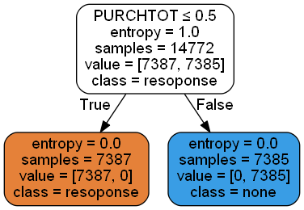

```python
dot_data = export_graphviz(ent_fit, out_file=None, feature_names=x_resampled.columns,
                           class_names=["resoponse", "none"],
                           filled=True, rounded=True, special_characters=True)
graph = pydotplus.graph_from_dot_data(dot_data)
Image(graph.create_png())
```

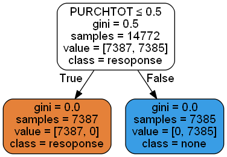

```python
dot_data = export_graphviz(gini_fit, out_file=None, feature_names=x_resampled.columns,
                           class_names=["resoponse", "none"],
                           filled=True, rounded=True, special_characters=True)
graph = pydotplus.graph_from_dot_data(dot_data)
Image(graph.create_png())
```

```python
##################################################################################3
#1.	데이터 불러오기 (CallsData.xls&ContractData.csv)
df2 = pd.read_excel('C:/Users/kyuri Im/Desktop/bigdata/Data_Study_19.05.19~/20190526 과제/20190526 과제/CallsData.xls',encoding='utf-8')
df3 = pd.read_csv('C:/Users/kyuri Im/Desktop/bigdata/Data_Study_19.05.19~/20190526 과제/20190526 과제/ContractData.csv')
```

```python
#2.	데이터 합치기
df = df2.merge(df3, on=['Area Code','Phone'], how='left')
```

```python
#3.	데이터 검토 및 통계분석
df.head()
```

|  | VMail Message | Day Mins | Eve Mins | Night Mins | Intl Mins | CustServ Calls | Day Calls | Day Charge | Eve Calls | Eve Charge | Night Calls | Night Charge | Intl Calls | Intl Charge | Area Code | Phone | Account Length | Churn | Int'l Plan | VMail Plan | State |
| --- | --- | --- | --- | --- | --- | --- | --- | --- | --- | --- | --- | --- | --- | --- | --- | --- | --- | --- | --- | --- | --- |
| 0 | 25 | 265.1 | 197.4 | 244.7 | 10.0 | 1 | 110 | 45.07 | 99 | 16.78 | 91 | 11.01 | 3 | 2.70 | 415 | 382-4657 | 128 | 0 | 0 | 1 | KS |
| 1 | 26 | 161.6 | 195.5 | 254.4 | 13.7 | 1 | 123 | 27.47 | 103 | 16.62 | 103 | 11.45 | 3 | 3.70 | 415 | 371-7191 | 107 | 0 | 0 | 1 | OH |
| 2 | 0 | 243.4 | 121.2 | 162.6 | 12.2 | 0 | 114 | 41.38 | 110 | 10.30 | 104 | 7.32 | 5 | 3.29 | 415 | 358-1921 | 137 | 0 | 0 | 0 | NJ |
| 3 | 0 | 299.4 | 61.9 | 196.9 | 6.6 | 2 | 71 | 50.90 | 88 | 5.26 | 89 | 8.86 | 7 | 1.78 | 408 | 375-9999 | 84 | 0 | 1 | 0 | OH |
| 4 | 0 | 166.7 | 148.3 | 186.9 | 10.1 | 3 | 113 | 28.34 | 122 | 12.61 | 121 | 8.41 | 3 | 2.73 | 415 | 330-6626 | 75 | 0 | 1 | 0 | OK |

```python
#4.	모델에 사용되지 않을 변수 제거(Phone, Account Length)
del df['Phone']
del df['Account Length']
```

```python
#5.	명목형 변수의 경우 수치형 일 때 -> String으로 변환-
```

```python
#6.	변수 표준화 (Normalizaion)
for i in range(0,15):
    df.iloc[:,i]=(df.iloc[:,i]-df.iloc[:,i].min())/(df.iloc[:,i].max()-df.iloc[:,i].min())
```

```python
#7.	학습용 데이터와 테스트 데이터 80:20으로 분리
from sklearn.tree import DecisionTreeClassifier,export_graphviz # Import Decision Tree Classifier
from sklearn.model_selection import train_test_split # Import train_test_split function
from sklearn import metrics #Import scikit-learn metrics module for accuracy calculation
import pydot
X =
X_train, X_test, y_train, y_test = train_test_split(X, Y, test_size=0.2, random_state=1)
'''
random_state : 데이터 분할시 셔플이 이루어지는데 이를 위한 시드값 (int나 RandomState로 입력)
shuffle : 셔플여부설정 (default = True)
stratify : 지정한 Data의 비율을 유지한다. 예를 들어, Y가 3:1의 두 클래스이면, stratify=Y로 설정하면 데이터셋들도 3:1.

'''

#8.	SMOTE로 목표변수(churn) 0과 1의 비율 맞추기
#9.	Gain Ratio Decision Tree 생성
#10.Gini Index Decision Tree 생성
#11.두 모델의 비교
```

```
  File "<ipython-input-26-1111fb3e3d3a>", line 6
    X =
        ^
SyntaxError: invalid syntax
```